# TP1: Clasificación binaria - Predicción de la comestibilidad de hongos

## Ejercicio 2: Preparación de los datos

**Carga del conjunto de datos y realizamiento del preprocesamiento**

```r
mushrooms <- read.csv('mushrooms_small.csv')

table(is.na(mushrooms)) #verificamos que no hay valores nulos
```

```
##
##  FALSE
## 967449
```

```r
nrow(mushrooms) #verificamos que hay menos de 50.000 observaciones
```

```
## [1] 46069
```

Como los datos ya se encuentran sampleados (menos de 50.000 observaciones) y sin valores null, para preprocesarlos encargaremos de: * cambiar los valores de las variables categóricas por palabras enteras en vez de letras. * quitar columnas que dependen de otras.

La fuente del dataset especifica que las columnas ‘gill-color’, ‘stem-surface’, ‘stem-color’, ‘veil-color’ y ‘spore-print-color’ dependen de ‘cap-color’ y ‘cap-surface’, así que decidimos eliminar estas columnas correlacionadas para disminuir al máximo posible el ruido, que podría distorsionar nuestra clasificación binaria.

```r
mushrooms <- mushrooms[, !(names(mushrooms) %in% c("gill.color", "stem.surface", "stem.color", "veil.color", "spore.print.color"))]
ncol(mushrooms)
```

```
## [1] 16
```

```r
head(mushrooms_renamed)
```

|  | class | cap.diameter | cap.shape | cap.surface | cap.color | does.bruise.or.bleed | gill.attachment | gill.spacing | stem.height | stem.width | stem.root | veil.type | has.ring | ring.type | habitat | season |
| --- | --- | --- | --- | --- | --- | --- | --- | --- | --- | --- | --- | --- | --- | --- | --- | --- |
| 1 | poisonous | 15.26 | convex | grooves | orange | false | free | none | 16.95 | 17.09 | swollen | universal | true | grooved | woods | winter |
| 2 | poisonous | 16.60 | convex | grooves | orange | false | free | none | 17.99 | 18.19 | swollen | universal | true | grooved | woods | summer |
| 3 | poisonous | 14.07 | convex | grooves | orange | false | free | close | 17.80 | 17.74 | swollen | universal | true | grooved | woods | winter |
| 4 | poisonous | 14.17 | flat | shiny | red | false | free | none | 15.77 | 15.98 | swollen | universal | true | pendant | woods | winter |
| 5 | poisonous | 15.34 | convex | grooves | orange | false | free | distant | 17.84 | 18.79 | swollen | universal | true | pendant | woods | summer |
| 6 | poisonous | 12.85 | flat | grooves | orange | false | free | none | 17.27 | 18.69 | swollen | universal | true | pendant | woods | autumn |

**Análisis exploratorio de datos: Estadísticas descriptivas y visualizaciones de las variables principales**

Inicialmente buscamos obtener estadísticas sencillas con el método $\texttt{summary}$, pero primero veamos de qué tipos de datos son nuestras variables. Encontramos solo dos tipos de datos en nuestro dataset: 3 variables de tipo $\texttt{numeric}$ **cap.diameter**, **stem.height** y **stem.width** y 13 categóricas de tipo $\texttt{character}$. Además, 3 de las 13 categóricas son binarias, incluyendo a nuestra variable a predecir **class**, que especifica si el hongo en cuestión es o no comestible (‘edible’ o ‘poisonous’).

```r
str(mushrooms_renamed)
```

```
## 'data.frame':    46069 obs. of  16 variables:
##  $ class               : chr  "poisonous" "poisonous" "poisonous" "poisonous" ...
##  $ cap.diameter        : num  15.3 16.6 14.1 14.2 15.3 ...
##  $ cap.shape           : chr  "convex" "convex" "convex" "flat" ...
##  $ cap.surface         : chr  "grooves" "grooves" "grooves" "shiny" ...
##  $ cap.color           : chr  "orange" "orange" "orange" "red" ...
##  $ does.bruise.or.bleed: chr  "false" "false" "false" "false" ...
##  $ gill.attachment     : chr  "free" "free" "free" "free" ...
##  $ gill.spacing        : chr  "none" "none" "close" "none" ...
##  $ stem.height         : num  16.9 18 17.8 15.8 17.8 ...
##  $ stem.width          : num  17.1 18.2 17.7 16 18.8 ...
##  $ stem.root           : chr  "swollen" "swollen" "swollen" "swollen" ...
##  $ veil.type           : chr  "universal" "universal" "universal" "universal" ...
##  $ has.ring            : chr  "true" "true" "true" "true" ...
##  $ ring.type           : chr  "grooved" "grooved" "grooved" "pendant" ...
##  $ habitat             : chr  "woods" "woods" "woods" "woods" ...
##  $ season              : chr  "winter" "summer" "winter" "winter" ...
```

Comenzamos por analizar la distribución de algunas variables. En primer lugar nos interesa análizar si tenemos una proporción más o menos pareja de los valores que toma **class**. Siendo que hay aproximadamente 44 observaciones de ‘edible’ para cada 55 observaciones de ‘poisonous’ nos aseguramos una buena distribución de valores para que el modelo tenga suficientes ejemplos de ambas clases para aprender y generalizar adecuadamente.

```r
num_edible <- sum(mushrooms_renamed$class == 'edible')
num_poisonous <- sum(mushrooms_renamed$class == 'poisonous')

prop_edible <- num_edible/(nrow(mushrooms_renamed))
prop_poisonous <- num_poisonous/(nrow(mushrooms_renamed))

print(paste("Edible:", num_edible, "(",round(prop_edible * 100, 2), "%)"))
```

```
## [1] "Edible: 20516 ( 44.53 %)"
```

```r
print(paste("Poisonous:", num_poisonous, "(",round(prop_poisonous * 100, 2), "%)"))
```

```
## [1] "Poisonous: 25553 ( 55.47 %)"
```

```r
selected_columns <- mushrooms_renamed[, c("cap.diameter", "stem.height", "stem.width")]
summary(selected_columns)
```

```
##   cap.diameter     stem.height      stem.width
##  Min.   : 0.380   Min.   : 0.00   Min.   :  0.00
##  1st Qu.: 3.480   1st Qu.: 4.63   1st Qu.:  5.19
##  Median : 5.860   Median : 5.95   Median : 10.16
##  Mean   : 6.709   Mean   : 6.57   Mean   : 12.14
##  3rd Qu.: 8.540   3rd Qu.: 7.73   3rd Qu.: 16.53
##  Max.   :62.340   Max.   :33.92   Max.   :103.91
```

```r
#install.packages("PerformanceAnalytics")
library("PerformanceAnalytics")
```

```r
mushrooms_renamed[] <- lapply(mushrooms_renamed, function(x) if (is.character(x)) as.factor(x) else x)
mushrooms_numeric <- data.frame(lapply(mushrooms_renamed, function(x) if (is.factor(x)) as.numeric(x) else x))

#chart.Correlation(mushrooms_numeric, histogram=TRUE, pch=19)
```

## Ejercicio 3: Construcción de un árbol de decisión básico

```r
mushrooms_renamed$cap.shape <- as.factor(mushrooms_renamed$cap.shape)
mushrooms_renamed$cap.surface <- as.factor(mushrooms_renamed$cap.surface)
mushrooms_renamed$cap.color <- as.factor(mushrooms_renamed$cap.color)
mushrooms_renamed$gill.attachment <- as.factor(mushrooms_renamed$gill.attachment)
mushrooms_renamed$gill.spacing <- as.factor(mushrooms_renamed$gill.spacing)
mushrooms_renamed$stem.root <- as.factor(mushrooms_renamed$stem.root)
mushrooms_renamed$ring.type <- as.factor(mushrooms_renamed$ring.type)
mushrooms_renamed$veil.type <- as.factor(mushrooms_renamed$veil.type)
mushrooms_renamed$habitat <- as.factor(mushrooms_renamed$habitat)
mushrooms_renamed$season <- as.factor(mushrooms_renamed$season)

mushrooms_renamed$class <- as.factor(mushrooms_renamed$class)
mushrooms_renamed$does.bruise.or.bleed <- as.factor(mushrooms_renamed$does.bruise.or.bleed)
mushrooms_renamed$has.ring <- as.factor(mushrooms_renamed$has.ring)
```

```r
library(dplyr)
set.seed(42) #semilla para replicabilidad

n <- nrow(mushrooms_renamed)
indices <- sample(1:n) #'mezclamos' primero el orden de las filas, para luego solo tomar de la 1:70%, 70%-85% y 85%-100%
train_size <- floor(0.7 * n)
valid_size <- floor(0.15 * n)

train_indices <- indices[1:train_size]
valid_indices <- indices[(train_size + 1):(train_size + valid_size)]
test_indices <- indices[(train_size + valid_size + 1):n]

#creamos los subsets de datos
train_set <- mushrooms_renamed[train_indices, ]
valid_set <- mushrooms_renamed[valid_indices, ]
test_set <- mushrooms_renamed[test_indices, ]
```

```r
library(rpart)

tree_model <- rpart(class ~ .,
                    data = train_set,
                    method = "class")
```

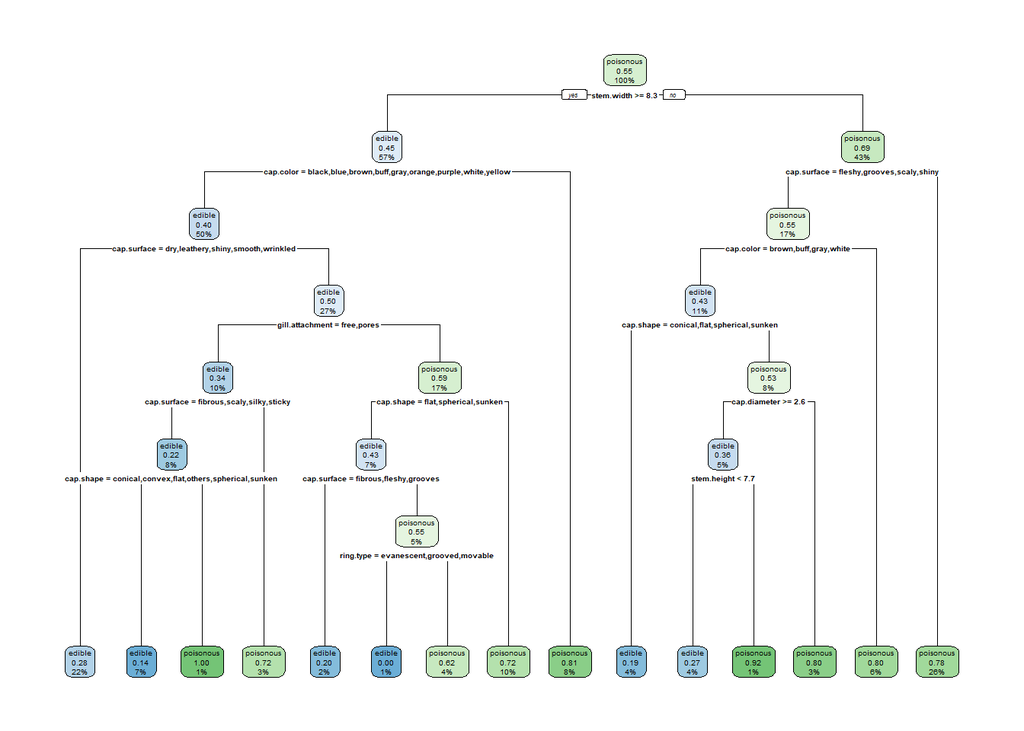

```r
library(rpart.plot)

rpart.plot(tree_model)
```

## Ejercicio 4: Evaluación del árbol de decisión básico

**Matriz de confusión**

```r
# Instalacion y/o importe de las librerias
# install.packages('caret')
library(caret)
# Predicciones de probabilidades y de clases
pred_prob <- predict(tree_model, test_set, type = "prob")  # Probabilidades predichas
pred_class <- predict(tree_model, test_set, type = "class")  # Clases predichas
```

Hacemos la Matriz de Confusión:

```r
conf_matrix <- confusionMatrix(pred_class, test_set$class)
print("Matriz de Confusión:")
```

```
## [1] "Matriz de Confusión:"
```

```r
print(conf_matrix$table)
```

```
##            Reference
## Prediction  edible poisonous
##   edible      2075       613
##   poisonous   1008      3215
```

```r
print(t(conf_matrix$table)) # traspongo para que sea como visto en clase
```

```
##            Prediction
## Reference   edible poisonous
##   edible      2075      1008
##   poisonous    613      3215
```

Lo que obtenemos es:

- $TP = 2075$: Es un True Positive que dice la cantidad de instancias donde el modelo predijo y la clase verdaderamente valia edible.
- $FP = 613$: Es un False Positive que dice la cantidad de instancias donde el modelo predijo edible, pero la clase verdaderamente valia poisonous.
- $FN = 1008$: Es un False Negative que dice la cantidad de instancias donde el modelo predijo poisonous, pero la clase verdaderamente valia edible.
- $TN = 3215$: Es un True Negative que dice la cantidad de instancias donde el modelo predijo poisonous y la clase clase verdaderamente valia poisonous.

Por lo tanto, usamos Accuracy como una metrica de evaluacion si el resultado fue bueno:

**Accuracy**

Buscamos ver la proporcion de predicciones correctas (tanto positivas como negativas) de las predicciones totales.

$$Accuracy = \frac{TP + TN}{P + N}
=$$
$$= \frac{TP + TN}{TP + FN + FP +
TN} =$$
$$= \frac{TP + TN}{TP + FN +
FP + TN} =$$
$$= \frac{2075 +
3215}{2075 + 1008 + 613 + 3215} =$$
$$= \frac{5290}{6911} = 0.7654464$$

En R:

```r
#
TP <- conf_matrix$table[1, 1]
FP <- conf_matrix$table[1, 2]
FN <- conf_matrix$table[2, 1]
TN <- conf_matrix$table[2, 2]

# Calculamos el accuracy
Accuracy <- (TP + TN) / (TP + FN + FP + TN)
Accuracy
```

```
## [1] 0.7654464
```

```r
# Validacion
conf_matrix$overall['Accuracy']
```

```
##  Accuracy
## 0.7654464
```

Esto significa que el modelo clasifica correctamente alrededor de 76.5% de las instancias.

Lo que significa que en este caso $Error rate = 1 - Accuracy = 0.2345536$.

Pero para considerar que las clases pueden llegar a estar desbalanceadas, usaremos Precision-Recall:

**Precision and Recall**

- Precision:

  Buscamos ver la proporcion de las instancias predichas de edible que verdaderamente valen edible.
  $$Precision_{edible} = \frac{TP}{TP + FP}
  =$$
  $$= \frac{2075}{2075 + 613} =
  0.7719494$$

  En R:

  ```r
  Precision <- TP/(TP + FP)
  Precision
  ```

  ```
  ## [1] 0.7719494
  ```

  ```r
  # Validacion
  conf_matrix$byClass['Pos Pred Value']
  ```

  ```
  ## Pos Pred Value
  ##      0.7719494
  ```

  Esto significa que alrededor de 77.2% del tiempo cuando el modelo predice edible acierta.
- Recall:

  Buscamos ver la proporcion de las instancias que verdaderamente valen edible que fueron correctamente predichas como edible.
  $$Recall_{edible} = \frac{TP}{TP + FN} =$$
  $$= \frac{2075}{2075 + 1008} =
  0.6730457$$

  En R:

  ```r
  Recall <- TP/(TP + FN)
  Recall
  ```

  ```
  ## [1] 0.6730457
  ```

  ```r
  # Validacion
  conf_matrix$byClass['Sensitivity']
  ```

  ```
  ## Sensitivity
  ##   0.6730457
  ```

  Esto significa que alrededor de 67.3% el modelo identifica correctamente si los hongos son comestibles.

Pero, queremos una ponderacion conjunta de Precision y de Recall, por lo cual usaremos F1-Score.

**F1-Score**

$$F1-Score = \frac{2 * Precision *
Recall}{Precision + Recall} =$$
$$=
\frac{2 * 0.7719494 * 0.6730457}{0.7719494 + 0.6730457} =
0.7191128$$

En R:

```r
F1_score <- (2 * Precision * Recall)/(Precision + Recall)
F1_score
```

```
## [1] 0.7191128
```

Esto significa que el accuracy del modelo en predicir la clase edible es igual a $0.7191128$.

**ROC-AUC Score**

Buscamos ver que tan bien el modelo tiene la capacidad de separar las clases.

```r
library(pROC)
```

```r
# Calculamos ROC curve
roc_curve <- roc(test_set$class, pred_prob[, "edible"])
#  AUC score
auc_value <- auc(roc_curve)
print(paste("AUC-ROC Score:", auc_value))
```

```
## [1] "AUC-ROC Score: 0.79219154760779"
```

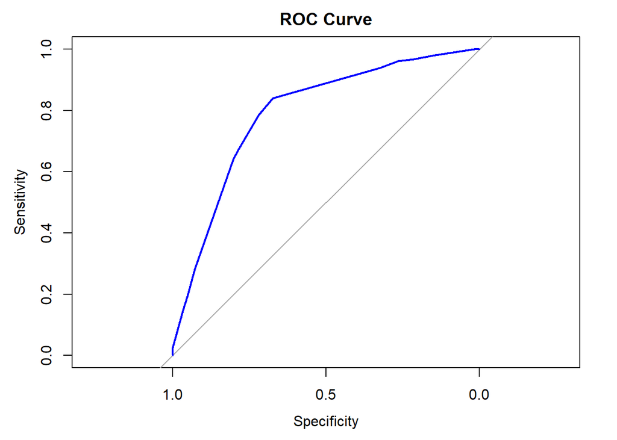

```r
# Plot de ROC curve
plot(roc_curve, main = "ROC Curve", col = "blue", lwd = 2)
```

$$AUC-ROC = 0.7921915$$

Esto significa que como $0.7921915 > 0.5$, el modelo se ejecuta mejor que hacer random guessing.